# Unit 2 Project

Fayez Eyabi

2026-02-07

# Lecture 06 Assignment

#Q1 ## The Briscoe Island has the most penguins. With theme_minimal(), I notice there is a lighter background and removes lots of the design not assosiated to the data plot itself.

```r
library("tidyverse")
library("palmerpenguins")
```

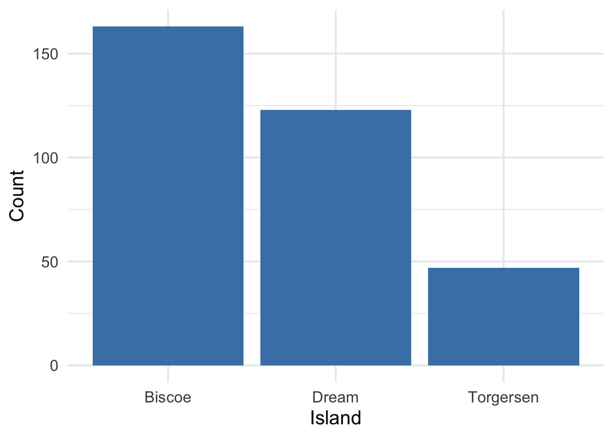

```r
penguins <- penguins %>%
  drop_na(flipper_length_mm, body_mass_g, bill_length_mm, bill_depth_mm, sex)
ggplot(penguins, aes(x=island)) + geom_bar(fill="steelblue")+labs(x="Island", y="Count")+theme_minimal(base_size = 16)
```

#Q2 ## This graph is slightly skewwed right and is unimodial. Upon chagning the bin number, I notice the bars change in thickness, refering to the amount of groups being grouped together. For Adelie, it appears some what asymmetric, Chinstrap appears assymetric and Gentoo appears bimodial. No, each species appears to have a unique mean.

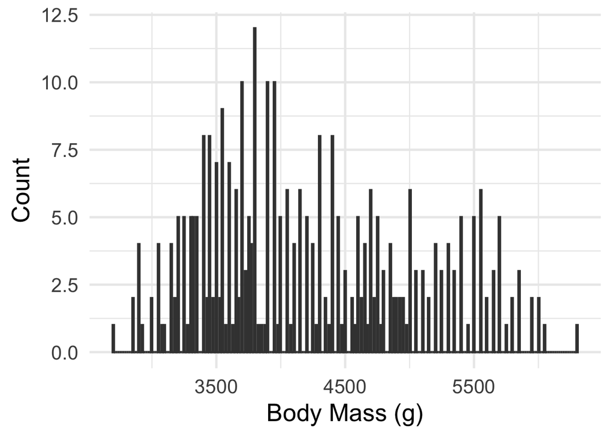

```r
ggplot(penguins, aes(x=body_mass_g))+geom_histogram(binwidth=9,fill="grey50", color="grey25")+labs(x="Body Mass (g)", y="Count")+theme_minimal(base_size=20)
```

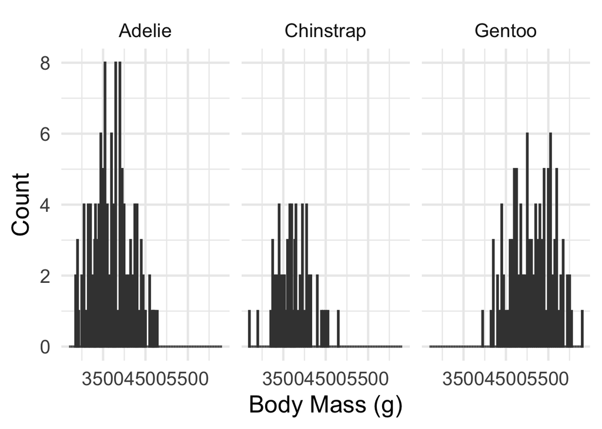

```r
ggplot(penguins, aes(x=body_mass_g))+geom_histogram(binwidth=9,fill="grey50", color="grey25")+facet_wrap(~species)+labs(x="Body Mass (g)", y="Count")+theme_minimal(base_size=20)
```

#Q3 ## Males have higher overall body mass and lead in all summary statistics. I personally saw no changes in the readilbility.

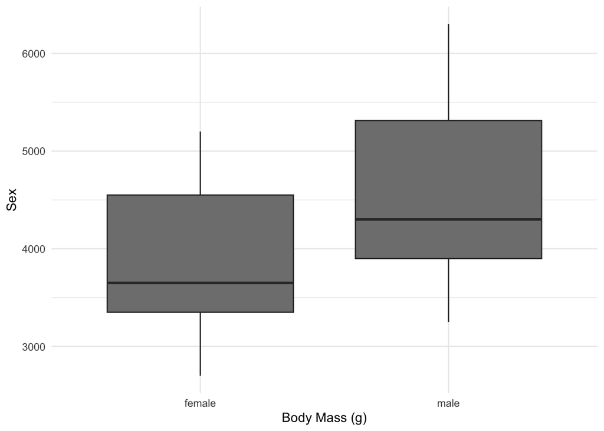

```r
ggplot(penguins, aes(x=sex,y=body_mass_g))+geom_boxplot(fill="grey50")+labs(x="Body Mass (g)", y="Sex")+theme_minimal()+scale_color_brewer(palette = "Set1")+
theme(legend.position = "none")
```

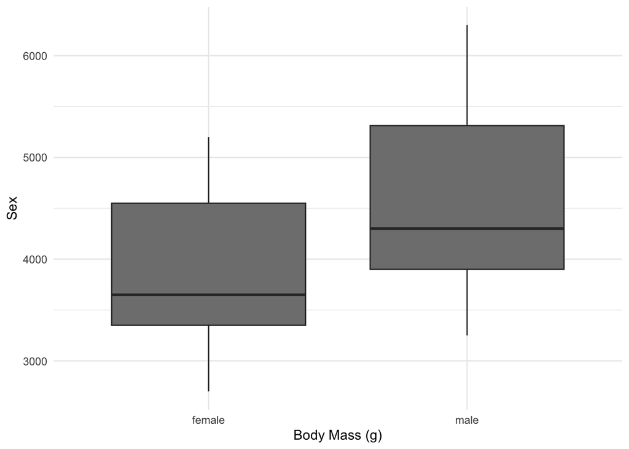

```r
ggplot(penguins, aes(x=sex,y=body_mass_g, fill=species))+geom_boxplot(fill="grey50")+labs(x="Body Mass (g)", y="Sex")+theme_minimal()+scale_color_brewer(palette = "Set1")+
theme(legend.position = "none")
```

#Q4 ## The trend is unclear. Now with adding color, each species has a unique amount of bill length. With the line, it fits the line moderately well, there are outliers which have leverage on the regression line.

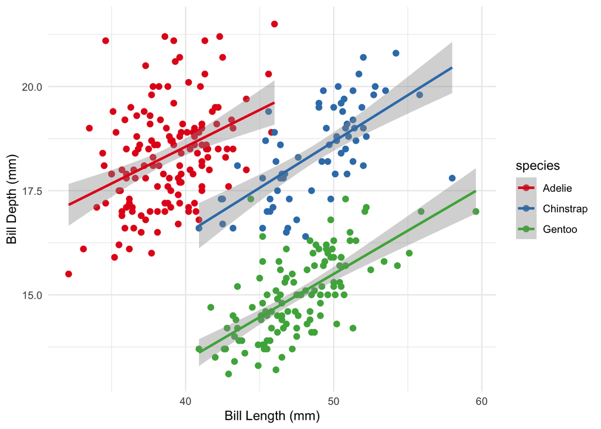

```r
ggplot(penguins,aes(x=bill_length_mm, y=bill_depth_mm, color=species))+geom_point(size=2)+geom_smooth(method = "lm") +labs(x="Bill Length (mm)", y="Bill Depth (mm)")+theme_minimal()+scale_color_brewer(palette="Set1")
```

#Q5 ##Flipper length increases as body mass increases

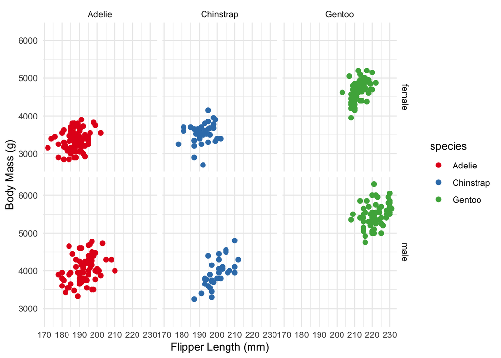

```r
ggplot(penguins,aes(x= flipper_length_mm, y=body_mass_g, color=species))+geom_point(size=2)+facet_grid(sex~species)+labs(x="Flipper Length (mm)", y="Body Mass (g)")+theme_minimal()+scale_color_brewer(palette="Set1")
```

#Q6

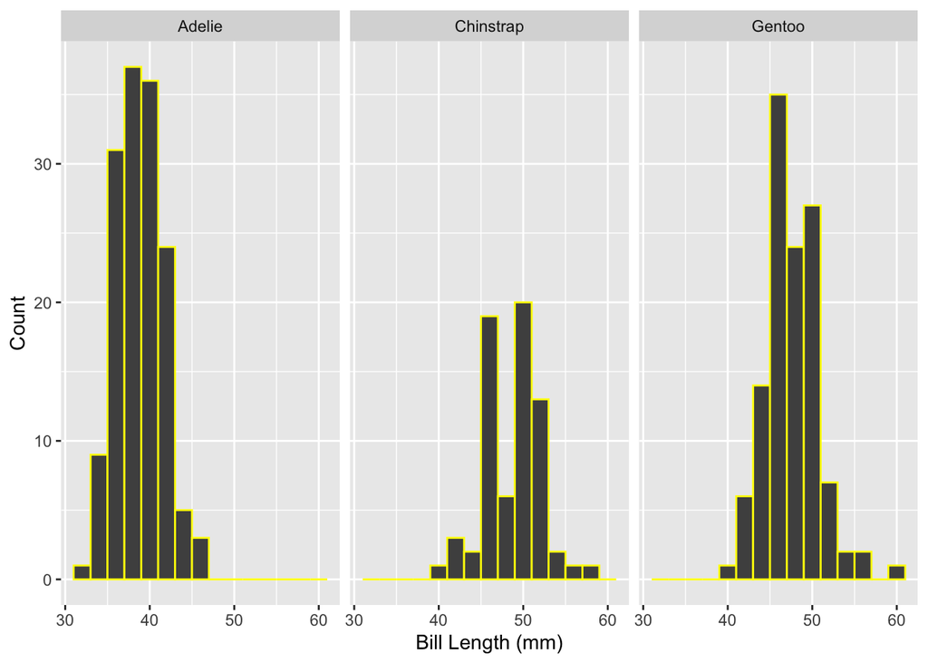

```r
ggplot(penguins, aes(x=bill_length_mm))+geom_histogram(binwidth=2,fill="grey31", color="yellow")+facet_wrap(~ species)+labs(x="Bill Length (mm)",y="Count")
```

#Q7

```r
#The most fun part was making the facet wrapping by species and the most confusing was making the final complex figure
```

# Lecture 07 Assignment

```r
library(palmerpenguins)
library(tidyverse)
library(stringr)
```

#Question 1

```r
penguins_messy <- read.csv("penguins_messy (1).csv")

str_detect(penguins_messy$species_messy, "adelie")
```

```
##   [1]  TRUE  TRUE  TRUE  TRUE  TRUE  TRUE  TRUE  TRUE  TRUE  TRUE  TRUE  TRUE
##  [13]  TRUE  TRUE  TRUE  TRUE  TRUE  TRUE  TRUE  TRUE  TRUE  TRUE  TRUE  TRUE
##  [25]  TRUE  TRUE  TRUE  TRUE  TRUE  TRUE  TRUE  TRUE  TRUE  TRUE  TRUE  TRUE
##  [37]  TRUE  TRUE  TRUE  TRUE  TRUE  TRUE  TRUE  TRUE  TRUE  TRUE  TRUE  TRUE
##  [49]  TRUE  TRUE  TRUE  TRUE  TRUE  TRUE  TRUE  TRUE  TRUE  TRUE  TRUE  TRUE
##  [61]  TRUE  TRUE  TRUE  TRUE  TRUE  TRUE  TRUE  TRUE  TRUE  TRUE  TRUE  TRUE
##  [73]  TRUE  TRUE  TRUE  TRUE  TRUE  TRUE  TRUE  TRUE  TRUE  TRUE  TRUE  TRUE
##  [85]  TRUE  TRUE  TRUE  TRUE  TRUE  TRUE  TRUE  TRUE  TRUE  TRUE  TRUE  TRUE
##  [97]  TRUE  TRUE  TRUE  TRUE  TRUE  TRUE  TRUE  TRUE  TRUE  TRUE  TRUE  TRUE
## [109]  TRUE  TRUE  TRUE  TRUE  TRUE  TRUE  TRUE  TRUE  TRUE  TRUE  TRUE  TRUE
## [121]  TRUE  TRUE  TRUE  TRUE  TRUE  TRUE  TRUE  TRUE  TRUE  TRUE  TRUE  TRUE
## [133]  TRUE  TRUE  TRUE  TRUE  TRUE  TRUE  TRUE  TRUE  TRUE  TRUE  TRUE  TRUE
## [145]  TRUE  TRUE  TRUE  TRUE  TRUE  TRUE  TRUE  TRUE FALSE FALSE FALSE FALSE
## [157] FALSE FALSE FALSE FALSE FALSE FALSE FALSE FALSE FALSE FALSE FALSE FALSE
## [169] FALSE FALSE FALSE FALSE FALSE FALSE FALSE FALSE FALSE FALSE FALSE FALSE
## [181] FALSE FALSE FALSE FALSE FALSE FALSE FALSE FALSE FALSE FALSE FALSE FALSE
## [193] FALSE FALSE FALSE FALSE FALSE FALSE FALSE FALSE FALSE FALSE FALSE FALSE
## [205] FALSE FALSE FALSE FALSE FALSE FALSE FALSE FALSE FALSE FALSE FALSE FALSE
## [217] FALSE FALSE FALSE FALSE FALSE FALSE FALSE FALSE FALSE FALSE FALSE FALSE
## [229] FALSE FALSE FALSE FALSE FALSE FALSE FALSE FALSE FALSE FALSE FALSE FALSE
## [241] FALSE FALSE FALSE FALSE FALSE FALSE FALSE FALSE FALSE FALSE FALSE FALSE
## [253] FALSE FALSE FALSE FALSE FALSE FALSE FALSE FALSE FALSE FALSE FALSE FALSE
## [265] FALSE FALSE FALSE FALSE FALSE FALSE FALSE FALSE FALSE FALSE FALSE FALSE
## [277] FALSE FALSE FALSE FALSE FALSE FALSE FALSE FALSE FALSE FALSE FALSE FALSE
## [289] FALSE FALSE FALSE FALSE FALSE FALSE FALSE FALSE FALSE FALSE FALSE FALSE
## [301] FALSE FALSE FALSE FALSE FALSE FALSE FALSE FALSE FALSE FALSE FALSE FALSE
## [313] FALSE FALSE FALSE FALSE FALSE FALSE FALSE FALSE FALSE FALSE FALSE FALSE
## [325] FALSE FALSE FALSE FALSE FALSE FALSE FALSE FALSE FALSE FALSE FALSE FALSE
## [337] FALSE FALSE FALSE FALSE FALSE FALSE FALSE FALSE
```

```r
str_replace_all(penguins_messy$sex_messy, "\\?", "")
```

```
##   [1] "M" "f" "f" NA  "f" "M" "f" "M" NA  NA  NA  NA  "f" "M" "M" "f" "f" "M"
##  [19] "f" "M" "f" "M" "f" "M" "M" "f" "M" "f" "f" "M" "f" "M" "f" "M" "f" "M"
##  [37] "M" "f" "f" "M" "f" "M" "f" "M" "f" "M" "M" NA  "f" "M" "f" "M" "f" "M"
##  [55] "f" "M" "f" "M" "f" "M" "f" "M" "f" "M" "f" "M" "f" "M" "f" "M" "f" "M"
##  [73] "f" "M" "f" "M" "f" "M" "f" "M" "f" "M" "f" "M" "f" "M" "M" "f" "M" "f"
##  [91] "f" "M" "f" "M" "f" "M" "f" "M" "f" "M" "f" "M" "f" "M" "f" "M" "f" "M"
## [109] "f" "M" "f" "M" "f" "M" "f" "M" "f" "M" "f" "M" "f" "M" "f" "M" "f" "M"
## [127] "f" "M" "f" "M" "f" "M" "f" "M" "f" "M" "f" "M" "f" "M" "f" "M" "f" "M"
## [145] "f" "M" "M" "f" "f" "M" "f" "M" "f" "M" "f" "M" "M" "f" "f" "M" "f" "M"
## [163] "f" "M" "f" "M" "f" "M" "f" "M" "f" "M" "M" "f" "f" "M" "f" "M" NA  "M"
## [181] "f" "M" "M" "f" "f" "M" "f" "M" "f" "M" "f" "M" "f" "M" "f" "M" "M" "f"
## [199] "f" "M" "f" "M" "f" "M" "f" "M" "f" "M" "f" "M" "f" "M" "f" "M" "f" "M"
## [217] "f" "M" NA  "M" "f" "M" "f" "M" "M" "f" "f" "M" "f" "M" "f" "M" "f" "M"
## [235] "f" "M" "f" "M" "f" "M" "f" "M" "f" "M" "f" "M" "f" "M" "M" "f" "f" "M"
## [253] "f" "M" "f" "M" NA  "M" "f" "M" "f" "M" "f" "M" "f" "M" "f" "M" NA  "M"
## [271] "f" NA  "f" "M" "f" "M" "f" "M" "M" "f" "M" "f" "f" "M" "f" "M" "f" "M"
## [289] "f" "M" "f" "M" "M" "f" "f" "M" "f" "M" "f" "M" "f" "M" "f" "M" "f" "M"
## [307] "f" "M" "f" "M" "M" "f" "f" "M" "f" "M" "M" "f" "M" "f" "f" "M" "f" "M"
## [325] "M" "f" "f" "M" "f" "M" "f" "M" "f" "M" "M" "f" "M" "f" "f" "M" "f" "M"
## [343] "M" "f"
```

```r
str_squish(penguins_messy$island_messy)
```

```
##   [1] "Torgersen" "Torgersen" "Torgersen" "Torgersen" "Torgersen" "Torgersen"
##   [7] "Torgersen" "Torgersen" "Torgersen" "Torgersen" "Torgersen" "Torgersen"
##  [13] "Torgersen" "Torgersen" "Torgersen" "Torgersen" "Torgersen" "Torgersen"
##  [19] "Torgersen" "Torgersen" "BIS-COE"   "BIS-COE"   "BIS-COE"   "BIS-COE"
##  [25] "BIS-COE"   "BIS-COE"   "BIS-COE"   "BIS-COE"   "BIS-COE"   "BIS-COE"
##  [31] "Dream"     "Dream"     "Dream"     "Dream"     "Dream"     "Dream"
##  [37] "Dream"     "Dream"     "Dream"     "Dream"     "Dream"     "Dream"
##  [43] "Dream"     "Dream"     "Dream"     "Dream"     "Dream"     "Dream"
##  [49] "Dream"     "Dream"     "BIS-COE"   "BIS-COE"   "BIS-COE"   "BIS-COE"
##  [55] "BIS-COE"   "BIS-COE"   "BIS-COE"   "BIS-COE"   "BIS-COE"   "BIS-COE"
##  [61] "BIS-COE"   "BIS-COE"   "BIS-COE"   "BIS-COE"   "BIS-COE"   "BIS-COE"
##  [67] "BIS-COE"   "BIS-COE"   "Torgersen" "Torgersen" "Torgersen" "Torgersen"
##  [73] "Torgersen" "Torgersen" "Torgersen" "Torgersen" "Torgersen" "Torgersen"
##  [79] "Torgersen" "Torgersen" "Torgersen" "Torgersen" "Torgersen" "Torgersen"
##  [85] "Dream"     "Dream"     "Dream"     "Dream"     "Dream"     "Dream"
```

[output cut: 43 more lines]

#Question 2

```r
penguins_messy_2<-penguins_messy %>%
  mutate(valid_id = str_detect(sample_id, "^PAL-\\d{3}$")) %>%pull(valid_id)%>%sum()
```

##Question 3

```r
penguins_messy %>%
  mutate(valid_id = str_detect(sample_id, "^PAL-\\d{3}$")) %>%filter(valid_id)
```

```
##     species_messy island_messy sex_messy sample_id
## 1          adelie  Torgersen\t         M   PAL-535
## 2          adelie  Torgersen\t        f?   PAL-442
## 3          adelie  Torgersen\t        f?   PAL-668
## 4          adelie  Torgersen\t      <NA>   PAL-920
## 5          adelie  Torgersen\t        f?   PAL-223
## 6          adelie  Torgersen\t         M   PAL-899
## 7          adelie  Torgersen\t        f?   PAL-268
## 8          adelie  Torgersen\t         M   PAL-139
## 9          adelie  Torgersen\t      <NA>   PAL-847
## 10         adelie  Torgersen\t      <NA>   PAL-238
## 11         adelie  Torgersen\t      <NA>   PAL-528
## 12         adelie  Torgersen\t      <NA>   PAL-365
## 13         adelie  Torgersen\t        f?   PAL-662
## 14         adelie  Torgersen\t         M   PAL-890
```

[output cut: 936 more lines]

##Question 4

```r
penguins_messy<-penguins_messy %>%
  mutate(file_dates=str_extract(file_name, "\\d{4}-\\d{2}-\\d{2}"))

penguins_messy<-penguins_messy %>%
  mutate(file_id=str_extract(file_name,"PAL-\\d{3}"))

penguins_messy$file_id[1:10]
```

```
##  [1] "PAL-535" "PAL-442" "PAL-668" "PAL-920" "PAL-223" "PAL-899" "PAL-268"
##  [8] "PAL-139" "PAL-847" "PAL-238"
```

```r
penguins_messy$file_dates[1:10]
```

```
##  [1] "2024-01-14" "2024-01-17" "2024-01-08" "2024-01-26" "2024-01-06"
##  [6] "2024-01-08" "2024-01-08" "2024-01-19" "2024-01-14" "2024-01-24"
```

##Question 5

```r
penguins_messy %>%
   mutate(island= str_squish(island_messy))
```

```
##     species_messy island_messy sex_messy sample_id
## 1          adelie  Torgersen\t         M   PAL-535
## 2          adelie  Torgersen\t        f?   PAL-442
## 3          adelie  Torgersen\t        f?   PAL-668
## 4          adelie  Torgersen\t      <NA>   PAL-920
## 5          adelie  Torgersen\t        f?   PAL-223
## 6          adelie  Torgersen\t         M   PAL-899
## 7          adelie  Torgersen\t        f?   PAL-268
## 8          adelie  Torgersen\t         M   PAL-139
## 9          adelie  Torgersen\t      <NA>   PAL-847
## 10         adelie  Torgersen\t      <NA>   PAL-238
## 11         adelie  Torgersen\t      <NA>   PAL-528
## 12         adelie  Torgersen\t      <NA>   PAL-365
## 13         adelie  Torgersen\t        f?   PAL-662
## 14         adelie  Torgersen\t         M   PAL-890
```

[output cut: 1365 more lines]

```r
penguins_messy$island
```

```
##   [1] "Torgersen\t" "Torgersen\t" "Torgersen\t" "Torgersen\t" "Torgersen\t"
##   [6] "Torgersen\t" "Torgersen\t" "Torgersen\t" "Torgersen\t" "Torgersen\t"
##  [11] "Torgersen\t" "Torgersen\t" "Torgersen\t" "Torgersen\t" "Torgersen\t"
##  [16] "Torgersen\t" "Torgersen\t" "Torgersen\t" "Torgersen\t" "Torgersen\t"
##  [21] "BIS-COE"     "BIS-COE"     "BIS-COE"     "BIS-COE"     "BIS-COE"
##  [26] "BIS-COE"     "BIS-COE"     "BIS-COE"     "BIS-COE"     "BIS-COE"
##  [31] "Dream  "     "Dream  "     "Dream  "     "Dream  "     "Dream  "
##  [36] "Dream  "     "Dream  "     "Dream  "     "Dream  "     "Dream  "
##  [41] "Dream  "     "Dream  "     "Dream  "     "Dream  "     "Dream  "
##  [46] "Dream  "     "Dream  "     "Dream  "     "Dream  "     "Dream  "
##  [51] "BIS-COE"     "BIS-COE"     "BIS-COE"     "BIS-COE"     "BIS-COE"
##  [56] "BIS-COE"     "BIS-COE"     "BIS-COE"     "BIS-COE"     "BIS-COE"
##  [61] "BIS-COE"     "BIS-COE"     "BIS-COE"     "BIS-COE"     "BIS-COE"
##  [66] "BIS-COE"     "BIS-COE"     "BIS-COE"     "Torgersen\t" "Torgersen\t"
##  [71] "Torgersen\t" "Torgersen\t" "Torgersen\t" "Torgersen\t" "Torgersen\t"
```

[output cut: 54 more lines]

```r
unique(penguins_messy$island_messy)
```

```
## [1] "Torgersen\t" "BIS-COE"     "Dream  "
```

##Question 6

```r
penguins_messy<- penguins_messy %>%
  mutate(sex= str_to_upper(str_replace_all(sex_messy,"\\?" , "")))

unique(penguins_messy$sex)
```

```
## [1] "M" "F" NA
```

##Question 7

```r
penguins_messy <-penguins_messy%>%  mutate(bill_mm= str_replace_all(notes, "(.*bill=)|mm", ""))

penguins_messy
```

```
##     species_messy island_messy sex_messy sample_id
## 1          adelie  Torgersen\t         M   PAL-535
## 2          adelie  Torgersen\t        f?   PAL-442
## 3          adelie  Torgersen\t        f?   PAL-668
## 4          adelie  Torgersen\t      <NA>   PAL-920
## 5          adelie  Torgersen\t        f?   PAL-223
## 6          adelie  Torgersen\t         M   PAL-899
## 7          adelie  Torgersen\t        f?   PAL-268
## 8          adelie  Torgersen\t         M   PAL-139
## 9          adelie  Torgersen\t      <NA>   PAL-847
## 10         adelie  Torgersen\t      <NA>   PAL-238
## 11         adelie  Torgersen\t      <NA>   PAL-528
## 12         adelie  Torgersen\t      <NA>   PAL-365
## 13         adelie  Torgersen\t        f?   PAL-662
## 14         adelie  Torgersen\t         M   PAL-890
```

[output cut: 1365 more lines]

##Question 8

```r
## I would say the most fun part was making the numeric column. The most confusing part was using regex to make the 2 columns. I feel after this assignment, I have a solid understanding of regular expressions.
```

# Lecture 08 Assignment

#Question 1

```r
penguins_clean<-penguins %>%
drop_na(bill_length_mm, sex)

nrow(penguins)
```

```
## [1] 333
```

```r
nrow(penguins_clean)
```

```
## [1] 333
```

#Question 2

```r
penguins_dup <- penguins_clean %>%
  bind_rows(slice_sample(penguins_clean, n = 30, replace = TRUE))
nrow(penguins_dup)
```

```
## [1] 363
```

#Answer: Duplication can lead to data inflation and distortion of the graphs and trends seen.

#Question 3

```r
new_penguin<-penguins_clean%>%select(species,island,sex, where(is.numeric))
ncol(new_penguin)
```

```
## [1] 8
```

#There are 8 columns in the dataframe

#Question 4

```r
penguins_clean%>%select(matches("^bill|flipper.*_mm$"))
```

```
## # A tibble: 333 × 3
##    bill_length_mm bill_depth_mm flipper_length_mm
##             <dbl>         <dbl>             <int>
##  1           39.1          18.7               181
##  2           39.5          17.4               186
##  3           40.3          18                 195
##  4           36.7          19.3               193
##  5           39.3          20.6               190
##  6           38.9          17.8               181
##  7           39.2          19.6               195
##  8           41.1          17.6               182
##  9           38.6          21.2               191
## 10           34.6          21.1               198
## # ℹ 323 more rows
```

#Question 5

```r
penguins_clean%>% group_by(species)%>%summarize(across(where(is.numeric),mean))
```

```
## # A tibble: 3 × 6
##   species   bill_length_mm bill_depth_mm flipper_length_mm body_mass_g  year
##   <fct>              <dbl>         <dbl>             <dbl>       <dbl> <dbl>
## 1 Adelie              38.8          18.3              190.       3706. 2008.
## 2 Chinstrap           48.8          18.4              196.       3733. 2008.
## 3 Gentoo              47.6          15.0              217.       5092. 2008.
```

##Answer: This method just saves time as it selects the specific columns from the dataset

#Question 6

```r
penguins_clean%>%
  mutate(bill_length=case_when(bill_length_mm<40~"short", bill_length_mm<50~"medium",bill_length_mm>=50~"long"))%>%select(bill_length_mm,bill_length )
```

```
## # A tibble: 333 × 2
##    bill_length_mm bill_length
##             <dbl> <chr>
##  1           39.1 short
##  2           39.5 short
##  3           40.3 medium
##  4           36.7 short
##  5           39.3 short
##  6           38.9 short
##  7           39.2 short
##  8           41.1 medium
##  9           38.6 short
## 10           34.6 short
## # ℹ 323 more rows
```

#Question 7

```r
instrument_meta <- tibble(
  instrument_id = c("caliper_A", "caliper_B", "caliper_C"),
  calibration_mm = c(0.2, 0.5, 1.0),
  manufacturer = c("Mitutoyo", "Fowler", "Generic")
)
penguins_instrumented<-penguins_clean%>%
  mutate(instrument_id =case_when( year == 2007~"caliper_A", year == 2008 ~"caliper_B",year == 2009~"caliper_C"))%>%drop_na(bill_length_mm)

penguins_instrumented<- penguins_instrumented %>% left_join(instrument_meta, by= "instrument_id")

ncol(penguins_instrumented)
```

```
## [1] 11
```

```r
ncol(penguins_clean)
```

```
## [1] 8
```

##Answer: I got 11 columns for penguins_instrumented and 8 columns for penguins_clean

#Question 8

```r
## I would say the most fun part was making the data set from penguins_clean. The most confusing part was making the data frame and incorporting the columns using left_join. These survival tips will be very useful!
```